# El lenguaje de programación R - Datos raster

Manuel Vargas

2020-06-11

## Recursos de interés

- [Geocomputation with R - Chapter 2 Geographic data in R - Raster data](https://geocompr.robinlovelace.net/spatial-class.html#raster-data)
- [Geocomputation with R - Chapter 3 Attribute data operations - Manipulating raster objects](https://geocompr.robinlovelace.net/attr.html#manipulating-raster-objects)
- [Geocomputation with R - Chapter 4 Spatial data operations - Spatial operations on raster data](https://geocompr.robinlovelace.net/spatial-operations.html#spatial-ras)
- [The raster package – R Spatial](https://rspatial.org/raster/pkg/)
- [raster: Geographic Data Analysis and Modeling](https://rdrr.io/cran/raster/)
- Sitio web del curso: [GF-0604: Procesamiento de datos geográficos](https://geoprocesamiento-2020i.github.io/).
- Datos utilizados durante el curso: [Datos del curso GF-0604: Procesamiento de datos geográficos](https://github.com/geoprocesamiento-2020i/datos).

## Preparativos

Paquetes

```r
# Paquete para manejo de datos vectoriales
library(sf)

# Paquete de Tidyverse para manipulación de datos
library(dplyr)

# Paquete para mapas en la Web
library(leaflet)
```

Datos para ejemplos

```r
# Registros de presencia de Ara ambiguus (lapa verde) en Costa Rica
cr_ara_ambiguus <-
  st_read(
    "https://raw.githubusercontent.com/geoprocesamiento-2020i/datos/master/biodiversidad/registros-presencia/cr/cr-ara-ambiguus.geojson"
  )
```

## El modelo de datos raster

El modelo de datos raster usualmente consiste de un encabezado y de una matriz con celdas (también llamadas pixeles) de un mismo tamaño. El encabezado define el [sistema de referencia de coordenadas (CRS)](https://en.wikipedia.org/wiki/Spatial_reference_system), la extensión y el punto de origen de una capa raster. Por lo general, el origen se ubica en la esquina inferior izquierda o en la esquina superior izquierda de la matriz. La extensión se define mediante el número de filas, el número de columnas y el tamaño (resolución) de la celda.

Cada celda tiene una identificación (ID) y almacena un único valor, el cual puede ser numérico o categórico, como se muestra en la figura 1.

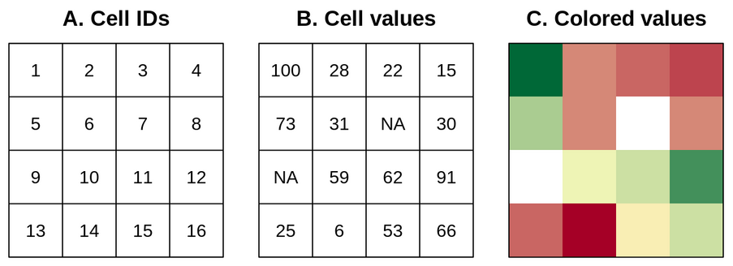

Figura 1: El modelo raster: (A) ID de las celdas, (B) valores de las celdas, (C) mapa raster de colores. Imagen de Robin Lovelace et al. (https://geocompr.robinlovelace.net/spatial-class.html#raster-data)

A diferencia del modelo vectorial, el modelo raster no necesita almacenar todas las coordenadas de cada geometría (i.e. las esquinas de las celdas), debido a que la ubicación de cada celda puede calcularse a partir de la información contenida en el encabezado. Esta simplicidad, en conjunto con el [álgebra de mapas](https://en.wikipedia.org/wiki/Map_algebra), permiten que el procesamiento de datos raster sea mucho más eficiente que el procesamiento de datos vectoriales. Por otra parte, el modelo vectorial es mucho más flexible en cuanto a las posibilidades de representación de geometrías y almacenamiento de valores, por medio de múltiples elementos de datos.

Los mapas raster generalmente almacenan fenómenos continuos como elevación, precipitación, temperatura, densidad de población y datos espectrales. También es posible representar mediante raster datos discretos, tales como tipos de suelo o clases de cobertura de la tierra, como se muestra en la figura 2.

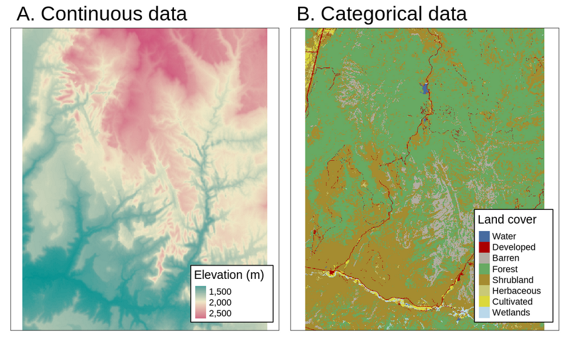

Figura 2: Ejemplos de mapas raster continuos y categóricos. Imagen de Robin Lovelace et al. (https://geocompr.robinlovelace.net/spatial-class.html#raster-data)

## El paquete raster

El paquete [raster](https://cran.r-project.org/web/packages/raster/) proporciona funciones para la lectura, escritura, manipulación, análisis y modelado de datos raster.

El paquete [rgdal](https://cran.r-project.org/web/packages/rgdal/) provee enlaces a las bibliotecas [GDAL](https://gdal.org/) y [PROJ](https://proj.org/).

### Instalación, carga y documentación

Instalación

```r
# Instalación del paquete raster
install.packages("raster")

# Instalación del paquete raster
install.packages("rgdal")
```

Carga

```r
# Carga del paquete raster
library(raster)

# Carga del paquete rgdal
library(rgdal)
```

Ayuda

```r
# Ayuda sobre paquete raster
help("raster-package")
```

Documentación:  
- [The raster package – R Spatial](https://rspatial.org/raster/pkg/)  
- [raster: Geographic Data Analysis and Modeling](https://rdrr.io/cran/raster/)

### Formatos raster

El paquete *raster* puede leer y escribir en una gran cantidad de [formatos raster](https://gdal.org/drivers/raster/) a través de la biblioteca GDAL.

### Uso básico

Para ejemplificar el uso del paquete `raster`, se accederá a la base de datos climáticos [WorldClim](https://www.worldclim.org/), mediante la función [getData()](https://rdrr.io/cran/raster/man/getData.html).

```r
# Directorio de trabajo (DEBE USARSE UN DIRECTORIO EXISTENTE EN EL DISCO)
setwd("c:/users/mfvargas/")

# Consulta del directorio de trabajo
getwd()
```

```
## [1] "c:/users/mfvargas"
```

```r
# Datos de altitud
altitude <- getData("worldclim", var="alt", res=.5, lon=-84, lat=10)

# Datos de altitud recortados para los límites aproximados de Costa Rica
cr_altitude <- crop(altitude, extent(-86, -82.3, 8, 11.3))

# Resumen de información básica de la capa raster
cr_altitude
```

```
## class      : RasterLayer
## dimensions : 396, 444, 175824  (nrow, ncol, ncell)
## resolution : 0.008333333, 0.008333333  (x, y)
## extent     : -86, -82.3, 8, 11.3  (xmin, xmax, ymin, ymax)
## crs        : +proj=longlat +datum=WGS84 +no_defs
## source     : memory
## names      : alt_23
## values     : -21, 3732  (min, max)
```

#### Tipos de datos

**RasterLayer**: almacena una sola capa.

```r
# Clase de cr_altitude
class(cr_altitude)
```

```
## [1] "RasterLayer"
## attr(,"package")
## [1] "raster"
```

```r
# Cantidad de capas
nlayers(cr_altitude)
```

```
## [1] 1
```

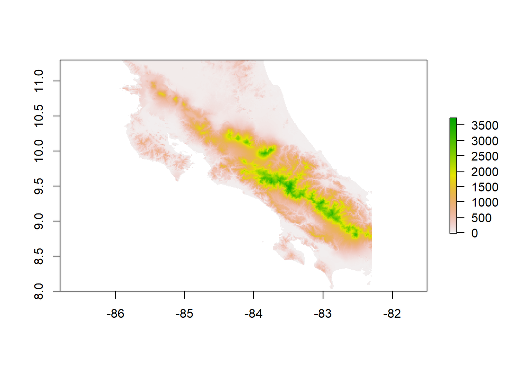

```r
# Mapeo
plot(cr_altitude)
```

**RasterBrick**: almacena varias capas, las cuales generalmente provienen de un mismo origen (ej. una imagen satelital).

```r
# Datos de precipitación
precipitation <- getData("worldclim", var="prec", res=.5, lon=-84, lat=10)

# Datos de precipitación recortados para los límites aproximados de Costa Rica
cr_precipitation <- crop(precipitation, extent(-86, -82.3, 8, 11.3))

# Clase de cr_precipitacion
class(cr_precipitation)
```

```
## [1] "RasterBrick"
## attr(,"package")
## [1] "raster"
```

```r
# Cantidad de capas
nlayers(cr_precipitation)
```

```
## [1] 12
```

```r
# Lista e información sobre las capas
unlist(cr_precipitation)
```

```
## class      : RasterBrick
## dimensions : 396, 444, 175824, 12  (nrow, ncol, ncell, nlayers)
## resolution : 0.008333333, 0.008333333  (x, y)
## extent     : -86, -82.3, 8, 11.3  (xmin, xmax, ymin, ymax)
## crs        : +proj=longlat +datum=WGS84 +no_defs
## source     : memory
## names      : prec1_23, prec2_23, prec3_23, prec4_23, prec5_23, prec6_23, prec7_23, prec8_23, prec9_23, prec10_23, prec11_23, prec12_23
## min values :        0,        0,        0,        9,      104,      179,      122,      154,       90,       140,        79,         7
## max values :      500,      293,      283,      372,      618,      659,      807,      673,      790,       829,       801,       752
```

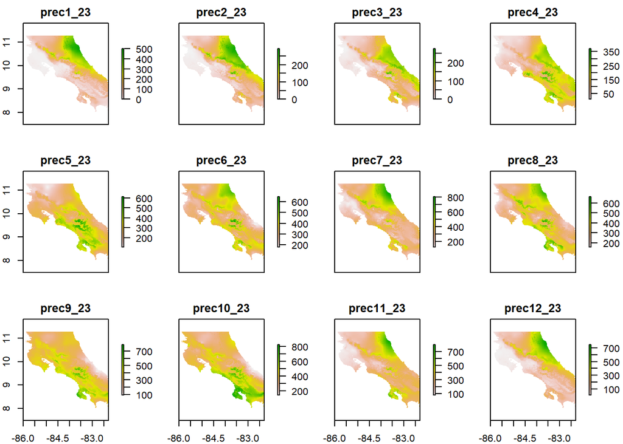

```r
# Mapeo
plot(cr_precipitation)
```

**RasterStack**: también almacena varias capas, pero a diferencia de `RasterBrick`, estas provienen de diferentes fuentes.

#### Confección de mapas

Ejemplo de mapa en Leaflet

```r
# Paleta de colores
pal <- colorNumeric(
  c("#0C2C84", "#41B6C4", "#FFFFCC"),
  values(cr_altitude),
  na.color = "transparent"
)

# Mapa web
m <- leaflet() %>%
  addProviderTiles(providers$Esri.WorldImagery, group = "Imágenes de ESRI") %>%
  addProviderTiles(providers$Stamen.TonerLite, group = "Stamen Toner Lite") %>%
  addProviderTiles(providers$OpenStreetMap.Mapnik, group = "OpenStreetMap") %>%
  addCircleMarkers(data = cr_ara_ambiguus,
                   stroke = F,
                   radius = 4,
                   fillColor = 'green',
                   fillOpacity = 1,
                   group = "Ara ambiguus",
                   popup = paste(cr_ara_ambiguus$locality,
                                 cr_ara_ambiguus$year,
                                 sep = '<br/>'
                           )
  ) %>%
  addRasterImage(cr_altitude,
                 colors = pal,
                 opacity = 0.8,
                 group = "Altitud"
  ) %>%
  addLayersControl(
    baseGroups = c("OpenStreetMap", "Stamen Toner Lite", "Imágenes de ESRI"),
    overlayGroups = c("Altitud", "Ara ambiguus"),
    options = layersControlOptions(collapsed = FALSE)
  ) %>%
  addLegend(pal = pal,
            values = values(cr_altitude),
            title = "Altitud"
  ) %>%
  addMiniMap(
    toggleDisplay = TRUE,
    position = "bottomleft",
    tiles = providers$Stamen.TonerLite
  )
```

```r
# Despliegue del mapa
m
```

[interactive chart not shown]

# Análisis

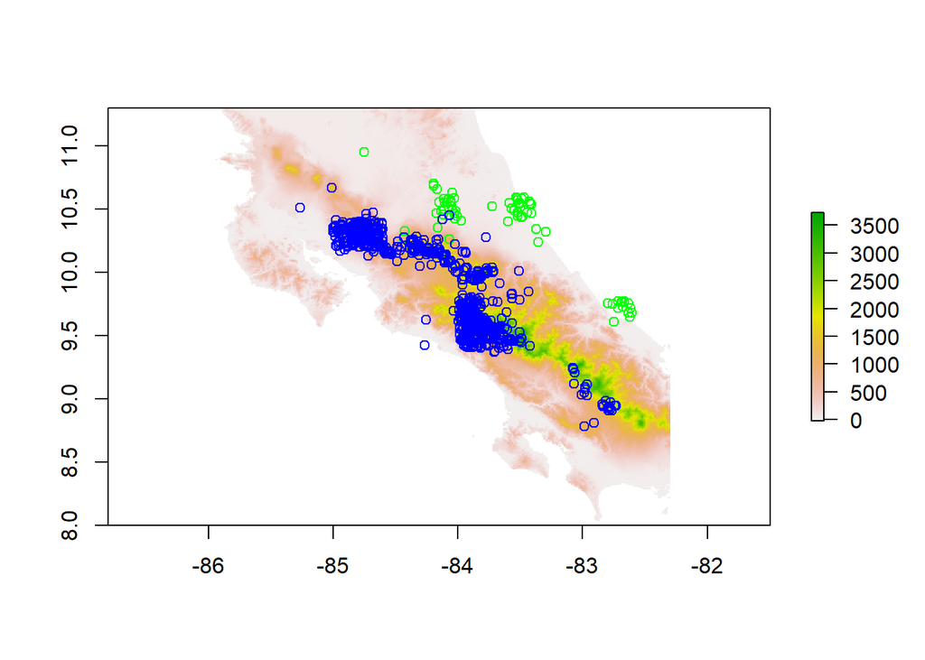

```r
# Directorio de trabajo (DEBE USARSE UN DIRECTORIO EXISTENTE EN EL DISCO)
setwd("c:/users/mfvargas/")

# Consulta del directorio de trabajo
getwd()

# Datos de altitud
altitude <- getData("worldclim", var="alt", res=.5, lon=-84, lat=10)

# Datos de altitud recortados para los límites aproximados de Costa Rica
cr_altitude <-
  getData("worldclim", var="alt", res=.5, lon=-84, lat=10) %>%
  crop(extent(-86, -82.3, 8, 11.3))

# Registros de presencia de Ara ambiguus (lapa verde) en Costa Rica
cr_ara_ambiguus <-
  st_read(
    "https://raw.githubusercontent.com/geoprocesamiento-2020i/datos/master/biodiversidad/registros-presencia/cr/cr-ara-ambiguus.geojson"
  )

# Registros de presencia de Pharomachrus mocinno (quetzal) en Costa Rica
cr_pharomachrus_mocinno <-
  st_read(
    "https://raw.githubusercontent.com/geoprocesamiento-2020i/datos/master/biodiversidad/registros-presencia/cr/cr_pharomachrus_mocinno.geojson"
  )


# Mapeo
plot(cr_altitude, axes=TRUE, graticule=TRUE, reset=FALSE)
plot(cr_ara_ambiguus, col="green", add=TRUE)
plot(cr_pharomachrus_mocinno, col="blue", add=TRUE)
```

```r
# Altitudes de los puntos de Ara ambiguus
alt_ara_ambiguus <- extract(cr_altitude, cr_ara_ambiguus)
# Impresión
alt_ara_ambiguus

# Altitudes de los puntos de Pharomachrus mocinno
alt_pharomachrus_mocinno <- extract(cr_altitude, cr_pharomachrus_mocinno)
# Impresión
alt_pharomachrus_mocinno
```

[output not shown]